# task3

```python
# task 3
# import libraries for this task
import pandas as pd
import json
import datetime
```

Step 1: Network overlap: with the "following.json" dataset, write a function that takes any two influencers' user ID's and calculate the fraction of followers these two influencers share over the total number of followers of the less followed influencer. The reference date is April 30, 2022.

```python
# import following.json into the same directory (on anacondas jupyter notebook) and import it into this file
# for analysis.
following_df = pd.read_json('following.json')
```

```python
following_df
```

|  | follower_uid | influencer_uid | follow_timestamp |
| --- | --- | --- | --- |
| 0 | 829451382935531520 | 902200087 | 2022-04-26 16:07:33 UTC |
| 1 | 2872039840 | 969221141347913728 | 2022-02-18 15:51:26 UTC |
| 2 | 1499994241979801600 | 14709326 | 2022-04-23 05:40:07 UTC |
| 3 | 1135376232839864320 | 836533158669500416 | 2022-04-28 13:26:38 UTC |
| 4 | 431066540 | 16106584 | 2017-04-14 11:35:28 UTC |
| ... | ... | ... | ... |
| 551130 | 78333251 | 158414847 | 2013-11-11 01:20:59 UTC |
| 551131 | 2802988291 | 158414847 | 2020-01-11 14:50:13 UTC |
| 551132 | 1519077442006261760 | 158414847 | 2022-04-27 01:35:00 UTC |
| 551133 | 2861786021 | 158414847 | 2019-07-21 14:38:03 UTC |
| 551134 | 1518751896810496000 | 158414847 | 2022-04-26 00:48:35 UTC |

551135 rows × 3 columns

```python
following_df.head() # look at the structure of the dataframe to see how i can format the function
```

|  | follower_uid | influencer_uid | follow_timestamp |
| --- | --- | --- | --- |
| 0 | 829451382935531520 | 902200087 | 2022-04-26 16:07:33 UTC |
| 1 | 2872039840 | 969221141347913728 | 2022-02-18 15:51:26 UTC |
| 2 | 1499994241979801600 | 14709326 | 2022-04-23 05:40:07 UTC |
| 3 | 1135376232839864320 | 836533158669500416 | 2022-04-28 13:26:38 UTC |
| 4 | 431066540 | 16106584 | 2017-04-14 11:35:28 UTC |

```python
following_df.dtypes # check the data types - we can see the 'follow_timestamp' column is a of type str.
```

```
follower_uid         int64
influencer_uid       int64
follow_timestamp    object
dtype: object
```

```python
# function for step 1)

# the set up of this function assumes that any dataframe u pass in has the same column names
# as the "following_df" dataset.

def shared_followers(df: pd.DataFrame, influencer1_id, influencer2_id):

    # filter data to include only entries from April 30, 2022
    filtered_data = df[df['follow_timestamp'].str.startswith('2022-04-30')]

    # get set of follower IDs for each influencer (each follower is unique)
    influencer1_followers = set(filtered_data[filtered_data['influencer_uid'] == influencer1_id]['follower_uid'])
    influencer2_followers = set(filtered_data[filtered_data['influencer_uid'] == influencer2_id]['follower_uid'])

    # calculate total number of unique followers for each influencer that they both share
    overlap_count = len(influencer1_followers.intersection(influencer2_followers))

    # calculate total number of followers of the less followed influencer
    total_followers = min(len(influencer1_followers), len(influencer2_followers))

    # calculate fraction of followers that two influencers share
    if total_followers > 0: # just in case the total_followers of that influencer are 0, we don't want a
        # ZeroDivError.

        overlap_fraction = overlap_count / total_followers
    else:
        return 0.0

        # just made the function return 0.0 when the lower influencer has 0 followers (no intersection between
        # any followers in this case)

    return overlap_fraction
```

```python
# example usage:
shared = shared_followers(following_df, 158414847, 158414847)
print(shared)
# makes sense that the same influencer has a fraction of 1.0 (all followers are same) on april 30th.
```

```
1.0
```

Step 2: Engagement overlap: with the "engagement.json" dataset, write a function that takes any two influencers' user ID's and calculate the fraction of engagers of these two influencers' tweets as a function of the total number of engagers of the less engaged influencer, over the period of April 22, 2022 to April 30, 2022.

```python
# import engagement.json into the same directory (on anacondas jupyter notebook) and import it into this file
engagement_df = pd.read_json('engagement.json')
```

```python
engagement_df.head()
```

|  | follower_uid | influencer_uid | engaged_tweetID | engaged_dt |
| --- | --- | --- | --- | --- |
| 0 | 1000041135396433920 | 1298372735383605248 | 1520185102143303680 | 2022-04-29 |
| 1 | 1000041135396433920 | 158414847 | 1520185102143303680 | 2022-04-29 |
| 2 | 1000041135396433920 | 288277167 | 1520185102143303680 | 2022-04-29 |
| 3 | 1000146462112665600 | 1022693675250249728 | 1518276445335961600 | 2022-04-24 |
| 4 | 1000146462112665600 | 10774652 | 1518276445335961600 | 2022-04-24 |

```python
engagement_df.dtypes # engaged_dt is an object
```

```
follower_uid        int64
influencer_uid      int64
engaged_tweetID     int64
engaged_dt         object
dtype: object
```

```python
def shared_engagements(dataset, influencer1_id, influencer2_id):
    # Step 1: Filter dataset based on date range and influencer IDs
    filtered_data = dataset[(dataset['engaged_dt'] >= '2022-04-22') & (dataset['engaged_dt'] <= '2022-04-30') &
                            ((dataset['influencer_uid'] == influencer1_id) | (dataset['influencer_uid'] == influencer2_id))]

    # Step 2: Group by influencer ID, engaged tweet ID, and follower ID, count unique tweet IDs
    grouped_data = filtered_data.groupby(['influencer_uid', 'engaged_tweetID', 'follower_uid']).size().reset_index(name='count')

    # Step 3: Get the total number of unique followers who engaged for each influencer
    influencer1_engagement = grouped_data[grouped_data['influencer_uid'] == influencer1_id]['follower_uid'].nunique()
    influencer2_engagement = grouped_data[grouped_data['influencer_uid'] == influencer2_id]['follower_uid'].nunique()

    # Step 4: Determine the less engaged influencer
    if influencer1_engagement < influencer2_engagement:
        less_engaged_followers = influencer1_engagement
    else:
        less_engaged_followers = influencer2_engagement

    # Step 5: Get unique followers who engaged in both influencers' tweets
    shared_engagers = set(grouped_data[grouped_data['influencer_uid'] == influencer1_id]['follower_uid']).intersection(
        set(grouped_data[grouped_data['influencer_uid'] == influencer2_id]['follower_uid'])
    )

    # Step 6: Calculate the fraction of shared engagers over the total unique followers of the less engaged influencer
    if less_engaged_followers > 0:
        fraction_engagers = len(shared_engagers) / less_engaged_followers
    else:
        return 0.0

    return fraction_engagers
```

```python
shared = shared_engagements(engagement_df, 158414847, 158414847)
print(shared)
# 2 same influencers have a 1.0 ratio of shared engagement of tweets within the same period of time.
```

```
1.0
```

```python
import matplotlib.pyplot as plt
```

```python
# network overlap - fraction of same followers on april 30th, bw 2 influencers
# engagement overlap - fraction of engaged tweets bw 22-30 of two influencers
```

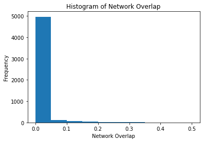

```python
# network overlap histogram

network_overlap = []
influencer_ids = list(following_df['influencer_uid'].unique())

# loop through all possible influencer pairs
for i in range(len(influencer_ids)):
    for j in range(i+1, len(influencer_ids)):
        # call shared_followers functions
        network_overlap.append(shared_followers(following_df, influencer_ids[i], influencer_ids[j]))

# create histogram for network overlap
plt.hist(network_overlap)
plt.xlabel('Network Overlap')
plt.ylabel('Frequency')
plt.title('Histogram of Network Overlap')
plt.show()
```

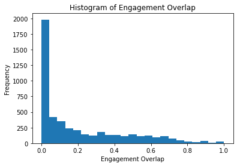

```python
# engagement overlap histogram
engagement_overlap = []
influencer_ids_2 = list(engagement_df['influencer_uid'].unique())

for i in range(len(influencer_ids_2)):
    for j in range(i+1, len(influencer_ids_2)):
        # call shared_engagements functions
        engagement_overlap.append(shared_engagements(engagement_df, influencer_ids_2[i], influencer_ids_2[j]))

# create histogram for engagement overlap
plt.hist(engagement_overlap, bins=23)
plt.xlabel('Engagement Overlap')
plt.ylabel('Frequency')
plt.title('Histogram of Engagement Overlap')
plt.show()
```

Step 5: Use OLS to regress engagement overlap on network overlap measures for all influencers pairs, and plot the regression results on a two-dimensional graph with standard error bands.

```python
# since the two influencer pairs have different lengths overthe two dataframes, im going to only use
# the pairs that are present in both. create an intersection between the lists first and then find the
# overlaps for those to run the regression, since we can't run regressions on 2 lists of different lengths.
new_set = list(set(influencer_ids) & set(influencer_ids_2))
new_set
```

[output not shown]

```python
# then find the network and engagement overlaps for only these influencers.
# not going to print the histograms for this: just the list
new_network_overlap = []

for i in range(len(new_set)):
    for j in range(i+1, len(new_set)):
        # call shared_followers functions
        new_network_overlap.append(shared_followers(following_df, influencer_ids[i], influencer_ids[j]))
```

```python
new_engagement_overlap = []

for i in range(len(new_set)):
    for j in range(i+1, len(new_set)):
        # call shared_engagements functions
        new_engagement_overlap.append(shared_engagements(engagement_df, influencer_ids[i], influencer_ids[j]))
```

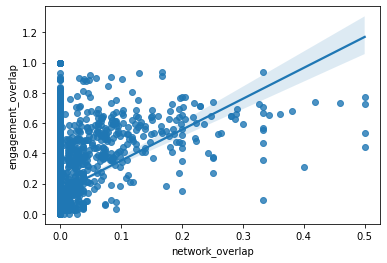

```python
import statsmodels.api as sm
import seaborn as sns

# create a dataframe with network overlap and engagement overlap measures
df_overlap = pd.DataFrame({'network_overlap': new_network_overlap,
                           'engagement_overlap':new_engagement_overlap })

# perform OLS regression
X = sm.add_constant(df_overlap['network_overlap'])
model = sm.OLS(df_overlap['engagement_overlap'], X)
results = model.fit()


# plot the results with standard error bands
sns.regplot(x='network_overlap', y='engagement_overlap', data=df_overlap, ci=95) #95th confidence interval
```

Step 6: Develop a hypothesis on the determinants of the difference between network vs engagement overlaps, i.e. what makes two influencers have high network overlap but low engagement overlap and vice versa?

One possible hypothesis on the determinants of the difference between network vs engagement overlaps could be related to the content and style of the tweets that the influencers are posting. For instance, two influencers might have a high network overlap because they have similar interests and followers, but their engagement overlap might be low if their tweeting styles are different or if they are covering different topics. Similarly, two influencers might have a low network overlap but a high engagement overlap if they are posting about similar topics but have different audiences. Another factor that could impact the difference between network vs engagement overlaps could be the frequency and timing of the tweets, as influencers might have different tweeting schedules and patterns that could affect how their followers engage with their content. Overall, there could be multiple factors that contribute to the difference between network vs engagement overlaps, and further research and analysis would be needed to identify and test these hypotheses.